# Multiclass Dry Bean Classification via Neural Networks

Automating Variety Identification from Image-Derived Morphological Features

Author

Anna Ly

Published

January 1, 2025

## Background

We will use the [UCI Dry Bean Dataset](https://doi.org/10.24432/C50S4B), originally featured in a classification study by Koklu & Özkan (2020). The dataset contains **13,611 samples** with image-based properties of seven bean types: Seker, Barbunya, Bombay, Cali, Dermason, Horoz, and Sira. The variables include **16 numeric features** derived from digital images, such as area, perimeter, major axis length, eccentricity, and compactness.

Sometimes there can be unlabeled beans, or farmers and companies may need an efficient way to identify different bean varieties. The goal is to use a neural network to classify the beans and evaluate whether these seven varieties can be accurately distinguished.

## Exploratory Analysis

**Show R code**

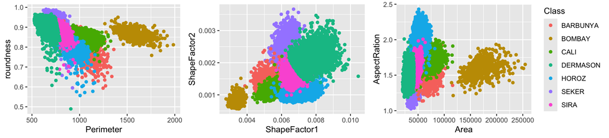

Scatterplots across pairs of morphological features. Bombay beans are clearly separable from all other varieties.

```r
grid.arrange(scatter1, scatter2, scatter3, ncol=3, nrow=1, widths=c(1, 1, 1.3))
```

**Show R code**

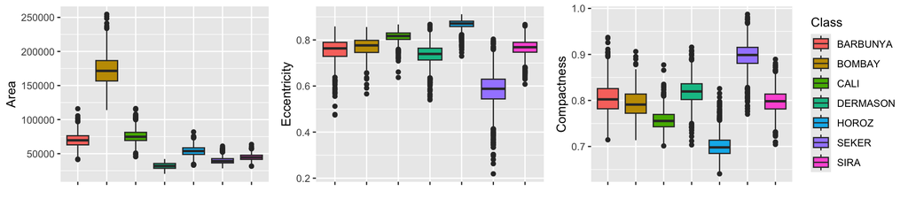

Distributions of area, eccentricity, and compactness by bean variety.

```r
grid.arrange(box1, box2, box3, ncol=3, nrow=1, widths=c(1, 1, 1.3))
```

Scatterplots show that Bombay beans stand out significantly across almost every variable. The remaining six varieties overlap considerably, which suggests that distinguishing among them will be more difficult.

The number of dry beans per variety is inconsistent. For instance, there are only 522 Bombay beans compared to 3,546 Sira beans. To ensure a representative sample for each variety, a **stratified 80/20 split** was used, sampling 80% from each class independently.

## Methods: Neural Networks

A feedforward neural network with a single hidden layer was trained using the `nnet` package. The architecture is:

$$f(x) = \beta_0 + \sum_{k=1}^{K} \beta_k \, g\!\left(w_{k0} + \sum_{j=1}^{p} w_{kj} x_j\right)$$

where $g(\cdot)$ is a nonlinear activation function applied in the hidden layer, $K$ is the number of hidden units (the **size** parameter), and the $w_{kj}$ are learned weights. For multiclass classification, a **softmax** output layer converts the final activations into class probabilities.

Two tuning parameters control the model:

- **Size** ($K$): number of hidden units, controlling model capacity.
- **Decay** ($\lambda$): L2 weight regularisation, controlling overfitting.

Both were selected via **5-fold cross-validation** over a grid of size ∈ {0, …, 20} and decay ∈ {0, …, 10}. The cross-validation recommended **size = 20, decay = 8**.

**Show R code**

```r
set.seed(2025)
train = c(sample(1:2027, 1622), sample(2028:3349, 1058), sample(3350:3871, 418),
          sample(3872:5501, 1304), sample(5502:7429, 1542), sample(7439:10065, 2109),
          sample(10066:13611, 2837))

y   = data$Class
x   = data[, -17]
cls = class.ind(as.factor(data[[17]]))

nnet_mod  = nnet(x[train,], cls[train,], size=20, decay=8, softmax=TRUE)
nnet_pred = predict(nnet_mod, x[-train,], type="class")

true_labels = as.factor(data[[17]][-train])
tab = table(true_labels, nnet_pred)
```

## Results

Confusion matrix: true labels (rows) vs. predicted labels (columns).

|  | BARBUNYA | CALI | DERMASON | HOROZ | SEKER | SIRA |
| --- | --- | --- | --- | --- | --- | --- |
| **BARBUNYA** | 1 | 253 | 0 | 7 | 3 | 0 |
| **BOMBAY** | 0 | 103 | 0 | 0 | 1 | 0 |
| **CALI** | 0 | 277 | 0 | 10 | 38 | 1 |
| **DERMASON** | 0 | 0 | 650 | 51 | 7 | 1 |
| **HOROZ** | 0 | 5 | 29 | 351 | 0 | 1 |
| **SEKER** | 0 | 11 | 21 | 0 | 373 | 0 |
| **SIRA** | 2 | 19 | 286 | 151 | 67 | 2 |

## Conclusion

Future studies could explore models with better interpretability, such as multinomial logistic regression, and compare their accuracy against the neural network.

## References

Koklu, M., & Özkan, I. A. (2020). Multiclass classification of dry beans using computer vision and machine learning techniques. *Computers and Electronics in Agriculture*, 174, 105507.

Dry Bean Dataset (2020). UCI Machine Learning Repository. https://doi.org/10.24432/C50S4B.